# HW1_Data_loading_function_and_usage

Cleaned Automobile Dataset Documentation Dataset Overview: The cleaned automobile dataset is derived from the UCI Machine Learning Repository's ["Automobile Data Set."](https://archive.ics.uci.edu/ml/machine-learning-databases/autos/imports-85.data) This dataset contains various continuous features related to automobile specifications and a target variable (price) representing the price of the car.

**File Details:**

- File Name: cleaned_automobile_data.pt
- File Format: PyTorch .pt file (serialized dictionary)
- Size: Varies based on the number of valid observations.
- Contents of the File:
- The .pt file contains the following keys:
- features: PyTorch tensor of shape (n_samples, 13)
- Description: Continuous numerical features related to automobile characteristics.
- target: PyTorch tensor of shape (n_samples, 1)
- Description: Price of the automobile (target variable).
- feature_names: List of strings (length 13)
- Description: Names of the feature columns:['wheel-base', 'length', 'width', 'height', 'curb-weight', 'engine-size', 'bore', 'stroke', 'compression-ratio', 'horsepower', 'peak-rpm', 'city-mpg', 'highway-mpg']
- target_name: String
- Description: Name of the target variable (price).

**Data Cleaning Details:**

- Missing Values Handling: Rows with missing values for any of the 13 continuous features or price were removed.
- Continuous Features: Only continuous features relevant to car specifications are retained.
- Target Variable: The price column was cleaned and reshaped for use in regression tasks.
- Dataset Shape: After cleaning, the dataset contains approximately 195 samples

```python
#1(a)
import torch
from IPython.core.pylabtools import figsize
#from requests.packages import target


# === Step 2: Loading the Dataset === #
def load_dataset(file_path):
    """
    Loads the saved PyTorch .pt dataset from the specified file path.

    This function reads a dataset saved in PyTorch format and extracts its features, target values,
    and relevant metadata. It prints the shapes of the feature matrix and target vector,
    as well as the feature and target names.

    Parameters:
    -----------
    file_path : str
        The file path to the saved .pt dataset.

    Returns:
    --------
    tuple
        A tuple containing:
        - features (torch.Tensor): A tensor containing the feature values.
        - target (torch.Tensor): A tensor containing the target values.
        - feature_names (list of str): A list of names corresponding to the feature columns.
        - target_name (str): The name of the target variable.

    Example:
    --------
    >>> features, target, feature_names, target_name = load_dataset("cleaned_automobile_train_dataset.pt")
    Loaded dataset successfully!
    Features shape: torch.Size([100, 13]), Target shape: torch.Size([100])
    Feature Names: ['wheel-base', 'length', 'width', ...], Target Name: 'price'
    """
    dataset = torch.load(file_path)
    print("Loaded dataset successfully!")
    print(f"Features shape: {dataset['features'].shape}, Target shape: {dataset['target'].shape}")
    print(f"Feature Names: {dataset['feature_names']}, Target Name: {dataset['target_name']}")
    return dataset["features"], dataset["target"], dataset["feature_names"], dataset["target_name"]

if __name__ == "__main__":
    #Load the dataset and display information
    print('loading train_dataset from cleaned_automobile_train_dataset.pt')
    X_train, Y_train, feature_names, target_name = load_dataset("cleaned_automobile_train_dataset.pt")
    print('number of training samples={}'.format(X_train.shape[0]))
    print('dimension of features={}'.format(X_train.shape[1]))
    print('X_train shape={}'.format(list(X_train.shape)))
    print('Y_train shape={}'.format(list(Y_train.shape)))

    print('loading test_dataset from cleaned_automobile_test_dataset.pt')
    X_test, Y_test, feature_names, target_name = load_dataset("cleaned_automobile_test_dataset.pt")
    print('number of test samples={}'.format(X_test.shape[0]))
    print('dimension of features={}'.format(X_test.shape[1]))
    print('X_test shape={}'.format(list(X_test.shape)))
    print('Y_test shape={}'.format(list(Y_test.shape)))
```

```
loading train_dataset from cleaned_automobile_train_dataset.pt
Loaded dataset successfully!
Features shape: torch.Size([156, 13]), Target shape: torch.Size([156, 1])
Feature Names: ['wheel-base', 'length', 'width', 'height', 'curb-weight', 'engine-size', 'bore', 'stroke', 'compression-ratio', 'horsepower', 'peak-rpm', 'city-mpg', 'highway-mpg'], Target Name: price
number of training samples=156
dimension of features=13
X_train shape=[156, 13]
Y_train shape=[156, 1]
loading test_dataset from cleaned_automobile_test_dataset.pt
Loaded dataset successfully!
Features shape: torch.Size([39, 13]), Target shape: torch.Size([39, 1])
Feature Names: ['wheel-base', 'length', 'width', 'height', 'curb-weight', 'engine-size', 'bore', 'stroke', 'compression-ratio', 'horsepower', 'peak-rpm', 'city-mpg', 'highway-mpg'], Target Name: price
number of test samples=39
dimension of features=13
X_test shape=[39, 13]
Y_test shape=[39, 1]
```

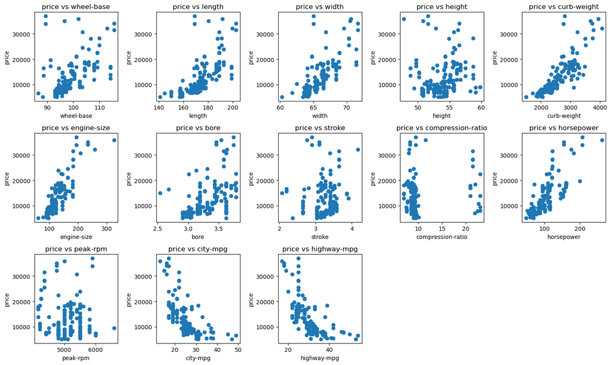

```python
#1(b)
import matplotlib.pyplot as plt

fig, ax = plt.subplots(3, 5, figsize = (15, 9))

for i in range(13):
    row, col = i//5, i%5
    ax[row, col].scatter(X_train[:, i], Y_train)
    ax[row, col].set_title(f"{target_name} vs {feature_names[i]}")
    ax[row, col].set_xlabel(feature_names[i])
    ax[row, col].set_ylabel(target_name)

for i in range(13, 15):
    fig.delaxes(ax[i//5, i%5])

plt.tight_layout()
plt.show()
```

# 1(c)

From the scatter plots, some features like length, width, curb-weight show strong positive relationships with the feature and the car's price, which makes them promising features. On the other hand, features like compression-ratio, bore, stroke and peak-rpm exhibit weaker or less consistent patterns, suggesting they may be unpromising features.

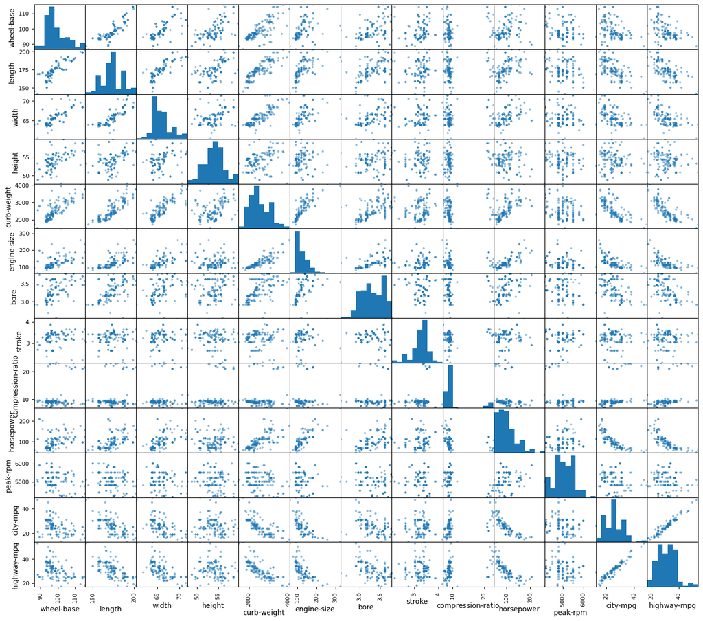

```python
#1(d)
import pandas as pd
import numpy as np
import seaborn as sns
import matplotlib.pyplot as plt

#convert features into Pandas.Dataframe
df = pd.DataFrame(X_train, columns=feature_names)
#print(df)

# Make a scatter plot matrix
pd.plotting.scatter_matrix(df, alpha = 0.5, figsize =(17,15), grid = False, range_padding = 0.01)
plt.show()
```

1(e)

From the scatterplot matrix, city-mpg and highway-mpg are highly correlated, as expected, given their similar nature. Additionally, certain features like curb-weight, engine-size, and horsepower show strong positive correlations with each other, indicating redundancy in the information they provide. Including all these features in a regression model could lead to multicollinearity issues.

Features to exclude:

1. Either city-mpg or highway-mpg.
2. Either curb-weight, engine-size, or horsepower.

2(a)

My proposed linear model is: $$ \phi(x) = \begin{bmatrix} x[1] \\ x[2] \\ x[5] \\ x[9] \\ 1 / x[11] \end{bmatrix}, $$ where x[1] represents length, x[2] represents width, x[5] represents engine-size, x[9] represents horsepower and x[11] represents city-mpg.

```python
#2(b)
def OLS(X, Y, lambda_reg=1e-10):
    Y = Y.squeeze()
    #use Gram matrix (X^T X)
    gram_matrix = torch.einsum('ji,ik->jk', (X.T, X))
    # add regulation λI
    gram_matrix += lambda_reg * torch.norm(gram_matrix) * torch.eye(gram_matrix.shape[0])
    # compute X^T Y
    v = torch.einsum('ji,i->j', (X.T, Y))
    # use torch.linalg.solve to solve linear function
    OLS_W = torch.linalg.solve(gram_matrix, v)

    return OLS_W

X_train_features = X_train[:, [1, 2, 5, 9, 11]]
X_train_features[:, 4] = 1 / X_train_features[:, 4]
target = Y_train.squeeze()

OLS_W = OLS(X_train_features, target, lambda_reg=1e-10)
print('OLS solution:', OLS_W)
```

```
OLS solution: tensor([ 1.0321e+02, -3.9142e+02,  1.2170e+02,  3.1317e+01,  5.4112e+04])
```

```python
#2(c)
import torch
from sklearn.metrics import mean_squared_error, r2_score

def calculate_metrics(X_train, Y_train, X_test, Y_test, W):
    """
    Calculate MSE and R2 scores for train and test datasets.
    """
    # Train set predictions
    Y_train_pred = torch.einsum('ij,j->i', (X_train, W))
    train_mse = mean_squared_error(Y_train.numpy(), Y_train_pred.numpy())
    train_r2 = r2_score(Y_train.numpy(), Y_train_pred.numpy())

    # Test set predictions
    Y_test_pred = torch.einsum('ij,j->i', (X_test, W))
    test_mse = mean_squared_error(Y_test.numpy(), Y_test_pred.numpy())
    test_r2 = r2_score(Y_test.numpy(), Y_test_pred.numpy())

    # Generalization gap
    generalization_gap = test_mse - train_mse

    return train_mse, train_r2, test_mse, test_r2, generalization_gap


# Assuming features and target have been split into train and test sets
# Train and test data (use your actual dataset splits)
#X_train_features = X_train[:, [1, 2, 4, 11]]
X_train_features = X_train[:, [1, 2, 5, 9, 11]]
X_train_features[:, 4] = 1 / X_train_features[:, 4]

#X_test_features = X_test[:, [1, 2, 4, 11]]
X_test_features = X_test[:, [1, 2, 5, 9, 11]]
X_test_features[:, 4] = 1 / X_test_features[:, 4]

# Fit OLS model
W = OLS(X_train_features, Y_train)

# Calculate metrics
train_mse, train_r2, test_mse, test_r2, generalization_gap = calculate_metrics(
    X_train_features, Y_train, X_test_features, Y_test, W
)

# Print results in a table
print(f"{'Dataset':<15}{'MSE':<15}{'R2':<15}")
print(f"{'-' * 45}")
print(f"{'Train':<15}{train_mse:<15.2f}{train_r2:<15.2f}")
print(f"{'Test':<15}{test_mse:<15.2f}{test_r2:<15.2f}")
print(f"{'-' * 45}")
print(f"{'Generalization Gap (Test MSE - Train MSE)':<15}{generalization_gap:<15.2f}")
```

[output not shown]

```
Train Set Performance:
```

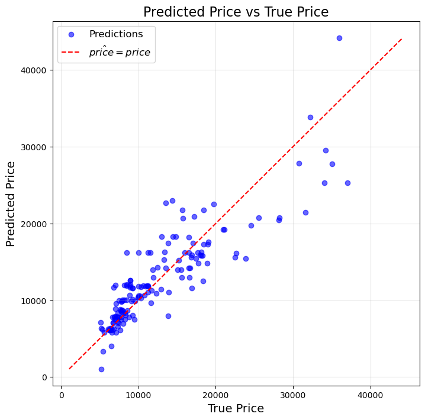

```
Test Set Performance:
```

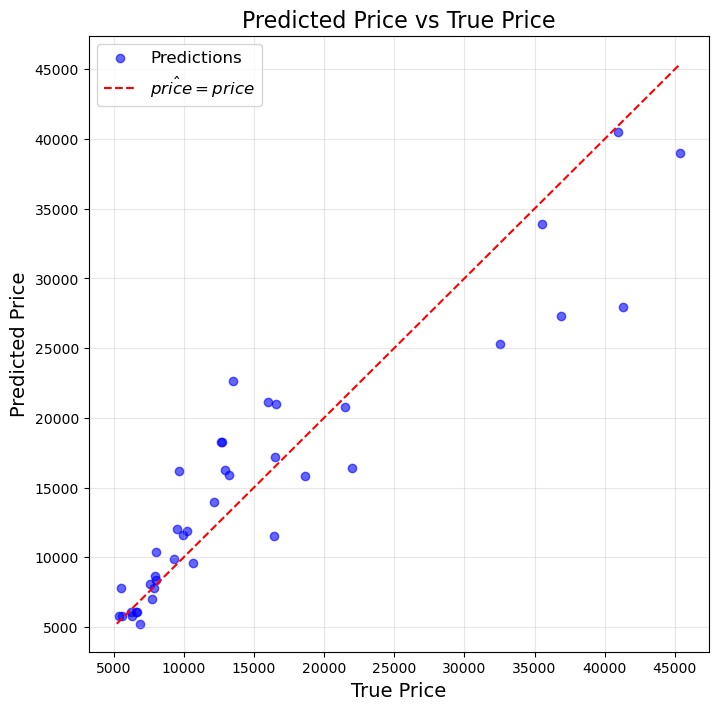

```python
#2(d)
import matplotlib.pyplot as plt
import torch

def plot_predictions(Y_true, Y_pred):
    """
    Scatter plot of predicted price (Y_pred) vs true price (Y_true).
    Also plots the line y = x for reference.
    """
    plt.figure(figsize=(8, 8))

    # Scatter plot of predicted vs true prices
    plt.scatter(Y_true.numpy(), Y_pred.numpy(), alpha=0.6, label="Predictions", color='blue')

    # Line y = x for perfect prediction
    max_val = max(Y_true.max(), Y_pred.max())
    min_val = min(Y_true.min(), Y_pred.min())
    plt.plot([min_val, max_val], [min_val, max_val], color="red", linestyle="--", label=r"$\hat{price} = price$")

    # Labels and legend
    plt.xlabel("True Price", fontsize=14)
    plt.ylabel("Predicted Price", fontsize=14)
    plt.title("Predicted Price vs True Price", fontsize=16)
    plt.legend(fontsize=12)
    plt.grid(alpha=0.3)

    # Show plot
    plt.show()

# Example usage with train/test predictions
# Assuming Y_train and Y_test are the true prices, Y_train_pred and Y_test_pred are the predicted prices
Y_train_pred = torch.einsum('ij,j->i', (X_train_features, OLS_W))
Y_test_pred = torch.einsum('ij,j->i', (X_test_features, OLS_W))

# Train set plot
print("Train Set Performance:")
plot_predictions(Y_train, Y_train_pred)

# Test set plot
print("Test Set Performance:")
plot_predictions(Y_test, Y_test_pred)
```

Based on the scatter plots, the model generally predicts well for lower and mid-range prices, but the largest deviations occur for higher true prices, where the model tends to underestimate the predicted values.

```python
#3(a)
def OLS(X, Y, lambda_reg=1e-10):
    Y = Y.squeeze()
    #use Gram matrix (X^T X)
    gram_matrix = torch.einsum('ji,ik->jk', (X.T, X))
    # add regulation λI
    gram_matrix += lambda_reg * torch.norm(gram_matrix) * torch.eye(gram_matrix.shape[0])
    # compute X^T Y
    v = torch.einsum('ji,i->j', (X.T, Y))
    # use torch.linalg.solve to solve linear function
    OLS_W = torch.linalg.solve(gram_matrix, v)

    return OLS_W

OLS_W = OLS(X_train, Y_train, lambda_reg=1e-10)
print('OLS solution:', OLS_W)
```

```
OLS solution: tensor([ 1.2607e+02, -8.5535e+01,  1.8263e+01,  4.9789e+01,  3.2736e+00,
         8.8934e+01, -2.2820e+03, -2.8570e+03,  3.6754e+02,  4.6614e+01,
         7.7912e-01, -3.3935e+02,  1.6029e+02])
```

```python
#3(b)
import torch
from sklearn.metrics import mean_squared_error, r2_score

def calculate_metrics(X_train, Y_train, X_test, Y_test, W):
    """
    Calculate MSE and R2 scores for train and test datasets.
    """
    # Train set predictions
    Y_train_pred = torch.einsum('ij,j->i', (X_train, W))
    train_mse = mean_squared_error(Y_train.numpy(), Y_train_pred.numpy())
    train_r2 = r2_score(Y_train.numpy(), Y_train_pred.numpy())

    # Test set predictions
    Y_test_pred = torch.einsum('ij,j->i', (X_test, W))
    test_mse = mean_squared_error(Y_test.numpy(), Y_test_pred.numpy())
    test_r2 = r2_score(Y_test.numpy(), Y_test_pred.numpy())

    # Generalization gap
    generalization_gap = test_mse - train_mse

    return train_mse, train_r2, test_mse, test_r2, generalization_gap


# Calculate metrics
train_mse, train_r2, test_mse, test_r2, generalization_gap = calculate_metrics(
    X_train, Y_train, X_test, Y_test, OLS_W
)

# Print results in a table
print(f"{'Dataset':<15}{'MSE':<15}{'R2':<15}")
print(f"{'-' * 45}")
print(f"{'Train':<15}{train_mse:<15.2f}{train_r2:<15.2f}")
print(f"{'Test':<15}{test_mse:<15.2f}{test_r2:<15.2f}")
print(f"{'-' * 45}")
print(f"{'Generalization Gap (Test MSE - Train MSE)':<15}{generalization_gap:<15.2f}")
```

```
Dataset        MSE            R2
---------------------------------------------
Train          8171388.50     0.83
Test           20374900.00    0.83
---------------------------------------------
Generalization Gap (Test MSE - Train MSE)12203512.00
```

3(c)

For minimizing the R2 error, I would choose the model the model in 3(b), because it behaves well in both datasets and it is more stable.

For minimizing the generalization gap, I would choose the model in 2(c), because its generalization gap is lower.